# STAT 420: Homework 3

Spring 2018, Hao Wang NetID: haow2

Due: Monday, February 19 by 11:30 PM CT

# Assignment

## Exercise 1 (Using `lm` for Inference)

For this exercise we will again use the `faithful` dataset. Remember, this is a default dataset in `R`, so there is no need to load it. You should use `?faithful` to refresh your memory about the background of this dataset about the duration and waiting times of eruptions of [the Old Faithful geyser](http://www.yellowstonepark.com/about-old-faithful/) in [Yellowstone National Park](https://en.wikipedia.org/wiki/Yellowstone_National_Park).

**(a)** Fit the following simple linear regression model in `R`. Use the eruption duration as the response and waiting time as the predictor.

$$Y_i = \beta_0 + \beta_1 x_i + \epsilon_i$$

Store the results in a variable called `faithful_model`. Use a $t$ test to test the significance of the regression. Report the following:

- The null and alternative hypotheses.
- The value of the test statistic.
- The p-value of the test.
- A statistical decision at $\alpha = 0.05$.
- A conclusion in the context of the problem.

When reporting these, you should explicitly state them in your document, not assume that a reader will find and interpret them from a large block of `R` output.

#### Solution:

```r
faithful_model = lm(eruptions~waiting, data=faithful)
```

$$H_0: \beta_1 = 0 \\
H_1: \beta_1 \neq 0$$

```r
my_test = summary(faithful_model)
my_t = my_test$coefficients[2,3]
my_pval = my_test$coefficients[2,4]
my_t
```

```
## [1] 34.08904
```

```r
my_pval
```

```
## [1] 8.129959e-100
```

```r
"Statistical decision:
Reject the null hypothesis at alpha = 0.05"

"Conclusion:
We can conclude that there this a strong linear relationship between eruptions duration and waiting time."
```

**(b)** Calculate a 95% confidence interval for $\beta_1$. Give an interpretation of the interval in the context of the problem.

#### Solution:

```r
beta_1_conf = confint(faithful_model, level = 0.95)[2,]
beta_1_conf
```

```
##      2.5 %     97.5 %
## 0.07126011 0.07999579
```

```
## we are 95% confident that for an increase in waiting time of 1 unit, the average increase in euption is between 0.07126011 and 0.07999579 times in mins, which is the interval for beta_1.
```

**(c)** Calculate a 99% confidence interval for $\beta_0$. Give an interpretation of the interval in the context of the problem.

```r
beta_0_conf = confint(faithful_model, level = 0.99)[1,]
beta_0_conf
```

```
##     0.5 %    99.5 %
## -2.289453 -1.458579
```

[output not shown]

**(d)** Use a 90% confidence interval to estimate the mean eruption duration for waiting times of 75 and 100 minutes. Which of the two intervals is wider? Why?

#### Solution:

```r
new_waiting = data.frame(waiting = c(75,100))
predict(faithful_model,newdata=new_waiting, interval = c("confidence"), level = 0.9)
```

```
##        fit      lwr      upr
## 1 3.798080 3.746169 3.849991
## 2 5.688779 5.571196 5.806361
```

```r
range(faithful$waiting)
```

```
## [1] 43 96
```

```r
"100 has high wider interval because it is out of the range of waiting time."
```

**(e)** Use a 90% prediction interval to predict the eruption duration for waiting times of 75 and 80 minutes.

```r
new_waiting = data.frame(waiting = c(75,80))
predict(faithful_model,newdata=new_waiting, interval = c("confidence"), level = 0.9)
```

```
##       fit      lwr      upr
## 1 3.79808 3.746169 3.849991
## 2 4.17622 4.116386 4.236054
```

**(f)** Create a scatterplot of the data. Add the regression line, 90% confidence bands, and 90% prediction bands.

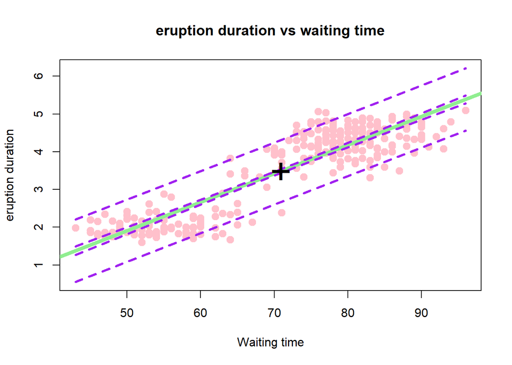

```r
wt_grid = seq(min(faithful$waiting), max(faithful$waiting),by = 0.01)
erup_ci_band = predict(faithful_model,
                       newdata = data.frame(waiting = wt_grid),
                       interval = "confidence", level = 0.90)
erup_pi_band = predict(faithful_model,
                       newdata = data.frame(waiting = wt_grid),
                       interval = "prediction", level = 0.90)
plot(eruptions ~ waiting, data = faithful,
     xlab = "Waiting time",
     ylab = "eruption duration",
     main = "eruption duration vs waiting time",
     pch = 20,
     cex = 2,
     col = "pink",
     ylim = c(min(erup_pi_band),max(erup_pi_band)))
abline(faithful_model, lwd = 5, col = "light green")
lines(wt_grid,erup_ci_band[,"lwr"],col = "purple", lwd = 3, lty = 2)
lines(wt_grid,erup_ci_band[,"upr"],col = "purple", lwd = 3, lty = 2)
lines(wt_grid,erup_pi_band[,"lwr"],col = "purple", lwd = 3, lty = 2)
lines(wt_grid,erup_pi_band[,"upr"],col = "purple", lwd = 3, lty = 2)
points(mean(faithful$waiting),mean(faithful$eruptions), pch = "+", cex =3)
```